# Rfit: Rank-based Estimation for Linear Models

John D. Kloke

Department of Biostatistics and Medical Informatics, University of Wisconsin-Madison

Joseph W. McKean

Department of Statistics, Western Michigan University

2012-12-01

Abstract

In the nineteen seventies, Jurečková and Jaeckel proposed rank estimation for linear models. Since that time, several authors have developed inference and diagnostic methods for these estimators. These rank-based estimators and their associated inference are highly efficient and are robust to outliers in response space. The methods include estimation of standard errors, tests of general linear hypotheses, confidence intervals, diagnostic procedures including studentized residuals, and measures of influential cases. We have developed an R package, [*Rfit*](https://CRAN.R-project.org/package=Rfit), for computing of these robust procedures. In this paper we highlight the main features of the package. The package uses standard linear model syntax and includes many of the main inference and diagnostic functions.

# Introduction

Rank-based estimators were developed as a robust, nonparametric alternative to traditional likelihood or least squares estimators. Rank-based regression was first introduced by Jurečková (1971) and Jaeckel (1972). McKean and T. Hettmansperger (1978) developed a Newton step algorithm that led to feasible computation of these rank-based estimates. Since then a complete rank-based inference for linear models has been developed that is based on rank-based estimation analogous to the way that traditional analysis is based on least squares (LS) estimation; see Chapters 3-5 of the monograph by Hettmansperger and McKean (2011) and Chapter 9 of Hollander and D. A. Wolfe (1999). Furthermore, robust diagnostic procedures have been developed with which to ascertain quality of fit and to locate outliers in the data; see McKean and S. Sheather (2009) for a recent discussion. Kloke, J. McKean, and M. Rashid (2009) extended this rank-based inference to mixed models. Thus rank-based analysis is a complete analysis analogous to the traditional LS analysis for general linear models. This rank-based analysis generalizes Wilcoxon procedures for simple location models and, further, it inherits the same high efficiency that these simple nonparametric procedures possess. In addition, weighted versions can have high breakdown (up to 50%) in factor space (Chang et al. 1999). In this paper, we discuss the [*Rfit*](https://CRAN.R-project.org/package=Rfit) package that we have developed for rank-based (R) estimation and inference for linear models. We illustrate its use on examples from simple regression to $k$-way factorial designs.

The geometry of rank-based estimation is similar to that of LS. In rank-based regression, however, we replace Euclidean distance with another measure of distance which we refer to as Jaeckel’s dispersion function; see Hettmansperger and McKean (2011) for details. For a brief overview see McKean (2004).

Jaeckel’s dispersion function depends on the choice of a score function. As discussed in Hettmansperger and McKean (2011), the rank-based fit and associated analysis can be optimized by a prudent choice of scores. If the form of the error distribution is known and the associated scores are used, then the the analysis is fully efficient. In *Rfit* we have included a library of score functions. The default option is to use Wilcoxon (linear) scores, however it is straightforward to create user-defined score functions. We discuss score functions further in a later section.

Others have developed software for rank-based estimation. Kapenga, McKean, and Vidmar (1995) developed a Fortran package and Crimin, Abebe, and McKean (2008) developed a web interface (cgi) with Perl for this Fortran program. Terpstra and McKean (2005) developed a set of R functions to compute weighted Wilcoxon (WW) estimates including the high breakdown point rank-based (HBR) estimate proposed by Chang et al. (1999). See McKean, J. Terpstra, and J. Kloke (2009) for a recent review. *Rfit* differs from the WW estimates in that its estimation algorithms are available for general scores and it uses a standard linear models interface.

The package *Rfit* allows the user to implement rank-based estimation and inference described in Chapters 3-5 of Hettmansperger and McKean (2011) and Chapter 9 of Hollander and D. A. Wolfe (1999). There are other robust packages in R. For example, the R function `rlm` of the R package [*MASS*](https://CRAN.R-project.org/package=MASS) (Venables and B. D. Ripley 2002) computes M estimates for linear models based on the $\psi$ functions of Huber, Hampel, and Tukey (bisquare). The CRAN Task View on robust statistical methods offers robust procedures for linear and nonlinear models including methods based on M, M-S, and MM estimators. These procedures, though, do not obtain rank-based estimates and associated inference as do the procedures in *Rfit*.

*Rfit* uses standard linear model syntax so that those familiar with traditional parametric analysis can easily begin running robust analyses. In this paper, discussion of the assumptions are kept to a minimum and we refer the interested reader to the literature. All data sets used in demonstrating *Rfit* are included in the package.

The rest of the paper is organized as follows. The next section discusses the general linear model and rank-based fitting and associated inference. The following section provides examples illustrating the computation of *Rfit* for linear regression. Later sections discuss *Rfit*’s computation of one-way and multi-way ANOVA as well as general scores and writing user-defined score functions for computation in *Rfit*. The final section discusses the future implementation in *Rfit* of rank-based procedures for models beyond the general linear model.

# Rank-regression

As with least squares, the goal of rank-based regression is to estimate the vector of coefficients, $\boldsymbol{\beta}$, of a general linear model of the form:

$$y_i = \alpha + \boldsymbol{x}_i^T
\boldsymbol{\beta}+ e_i \quad \text{for $i = 1, \ldots n$}
\label{eq:mod1} (\#eq:mod1)$$

where $y_i$ is the response variable, $\boldsymbol{x}_i$ is the vector of explanatory variables, $\alpha$ is the intercept parameter, and $e_i$ is the error term. We assume that the errors are iid with probability density function (pdf) $f(t)$. For convenience, we write (@ref(eq:mod1)) in matrix notation as follows

$$\boldsymbol{y}= \alpha \boldsymbol{1}+
\boldsymbol{X}\boldsymbol{\beta}+ \boldsymbol{e}
\label{eq:mod2} (\#eq:mod2)$$

where $\boldsymbol{y}= [y_1, \ldots, y_n]^T$ is the $n\times 1$ vector of responses, $\boldsymbol{X}= [\boldsymbol{x}_1, \ldots, \boldsymbol{x}_n]^T$ is the $n\times p$ design matrix, and $\boldsymbol{e}= [e_1, \ldots, e_n]^T$ is the $n \times 1$ vector of error terms. The only assumption on the distribution of the errors is that it is continuous; in that sense the model is general. Recall that the least squares estimator is the minimizor of Euclidean distance between $\boldsymbol{y}$ and $\hat{\boldsymbol{y}}_{LS} = \boldsymbol{X}\hat{\boldsymbol{\beta}}_{LS}$. To obtain the R estimator, a different measure of distance is used that is based on the dispersion function of Jaeckel (1972). Jaeckel’s dispersion function is given by

$$D(\boldsymbol{\beta}) = \|
\boldsymbol{y}- \boldsymbol{X}\boldsymbol{\beta}\|_\varphi
\label{eq:jaeckeldisp} (\#eq:jaeckeldisp)$$

where $\|\cdot\|_\varphi$ is a pseudo-norm defined as
$$\|\boldsymbol{u}\|_\varphi = \sum_{i=1}^n
a(R(u_i)) u_i,$$
where $R$ denotes rank, $a(t) = \varphi\left(\frac{t}{n+1}\right),$ and $\varphi$ is a non-decreasing, square-integrable *score* function defined on the interval $(0,1)$. Assume without loss of generality that it is standardized, so that $\int \varphi(u)\, du = 0$ and $\int \varphi^2(u)\, du = 1$. Score functions are discussed further in a later section.

The R estimator of $\boldsymbol{\beta}$ is defined as

$$\hat{\boldsymbol{\beta}}_\varphi =
\mbox{Argmin} \| \boldsymbol{y}-
\boldsymbol{X}\boldsymbol{\beta}\|_\varphi.
\label{eq:betahatR} (\#eq:betahatR)$$

This estimator is a highly efficient estimator which is robust in the $Y$-space. A weighted version can attain 50% breakdown in the $X$-space at the expense of a loss in efficiency (Chang et al. 1999).

## Inference

Under assumptions outlined in the previous section, it can be shown that the solution to (@ref(eq:betahatR)) is consistent and asymptotically normal (Hettmansperger and McKean 2011). We summarize this result as follows:
$$\hat{\boldsymbol{\beta}}_\varphi \dot \sim
N\left(\boldsymbol{\beta}, \tau_\varphi^2
(\boldsymbol{X}^T\boldsymbol{X})^{-1} \right)$$
where $\tau_\varphi$ is a scale parameter which depends on $f$ and the score function $\varphi$. An estimate of $\tau_\varphi$ is necessary to conduct inference and *Rfit* implements the consistent estimator proposed by Koul, Sievers, and McKean (1987). Denote this estimator by $\hat{\tau}_\varphi$. Then Wald tests and confidence regions/intervals can be calculated. Let $\mbox{se}(\hat{\beta}_j) = \hat{\tau}_\varphi \left( \boldsymbol{X}^T \boldsymbol{X}\right)^{-1}_{jj}$ where $\left( \boldsymbol{X}^T \boldsymbol{X}\right)^{-1}_{jj}$ is the $j$th diagonal element of $\left( \boldsymbol{X}^T \boldsymbol{X}\right)^{-1}$. Then an approximate $(1-\alpha)* 100\%$ confidence interval for $\beta_j$ is
$$\hat{\beta}_j \pm t_{1-\alpha/2,n-p-1}
\mbox{se}(\hat{\beta}_j).$$
A Wald test of the general linear hypothesis
$$H_0:
\boldsymbol{M}\boldsymbol{\beta}= \boldsymbol{0}\mbox{ versus } H_A:
\boldsymbol{M}\boldsymbol{\beta}\ne \boldsymbol{0}$$
is to reject $H_0$ if

$$\frac{(\boldsymbol{M}\hat{\boldsymbol{\beta}}_{\varphi})^T
[\boldsymbol{M}(\boldsymbol{X}^T\boldsymbol{X})^{-1})\boldsymbol{M}^T]^{-1}
(\boldsymbol{M}\hat{\boldsymbol{\beta}})/q}{\hat{\tau}_\varphi^2} >
F_{1-\alpha, q, n-p-1}$$

## Computation

It can be shown that Jaeckel’s dispersion function (@ref(eq:jaeckeldisp)) is a convex function of $\boldsymbol{\beta}$ (Hettmansperger and McKean 2011). *Rfit* uses `optim` with option `‘BFGS’` to minimize the dispersion function. We investigated other minimization methods (e.g. Nelder-Mead or CG), however the quasi-Newton method works well in terms of speed and convergence. An orthonormal basis matrix, for the space spanned by the columns of $\boldsymbol{X}$, is first calculated using `qr` which leads to better performance in examples. The default initial fit is based on an $L_1$ fit using [*quantreg*](https://CRAN.R-project.org/package=quantreg) (Koenker 2011).

Computations by *Rfit* of rank-based estimation and associated inference are illustrated in the examples of the next section.

# *Rfit* computations of rank-based fitting of linear models

For the general linear model @ref(eq:mod1) the package *Rfit* obtains the rank-based estimates and inference, as described in the previous section. In this section we illustrate this computation for two examples. The first is for a simple linear model while the second is for a multiple regression model.

#### Example 1: Telephone data

We begin with a simple linear regression example using the telephone data discussed in Rousseuw and Leroy (1987) These data represent the number of telephone calls (in tens of millions) placed in Belgium over the years 1950–1973. The data are plotted in Figure 1. There are several noticeable outliers which are due to a mistake in the recording units for the years 1964–1969. This is a simple dataset, containing only one explanatory variable, however it allows us to easily highlight the package and also demonstrate the robustness to outliers of the procedure. The main function of the package *Rfit* is `rfit` which, as the following code segment illustrates, uses syntax similar to `lm`.

```r
> library(Rfit)
> data(telephone)
> fit <- rfit(calls ~ year, data = telephone)
> summary(fit)
```

```r
Call:
rfit(formula = calls ~ year, data = telephone)

Coefficients:
        Estimate  Std. Error t.value p.value
     -284.313842  152.687751 -1.8621 0.07665 .
year    0.145861    0.077842  1.8738 0.07494 .
---
Signif. codes:
     0 ‘***’ 0.001 ‘**’ 0.01 ‘*’ 0.05 ‘.’ 0.1 ‘ ’ 1

Multiple R-squared (Robust): 0.3543158
Reduction in Dispersion Test:
     12.07238 p-value: 0.00215
```

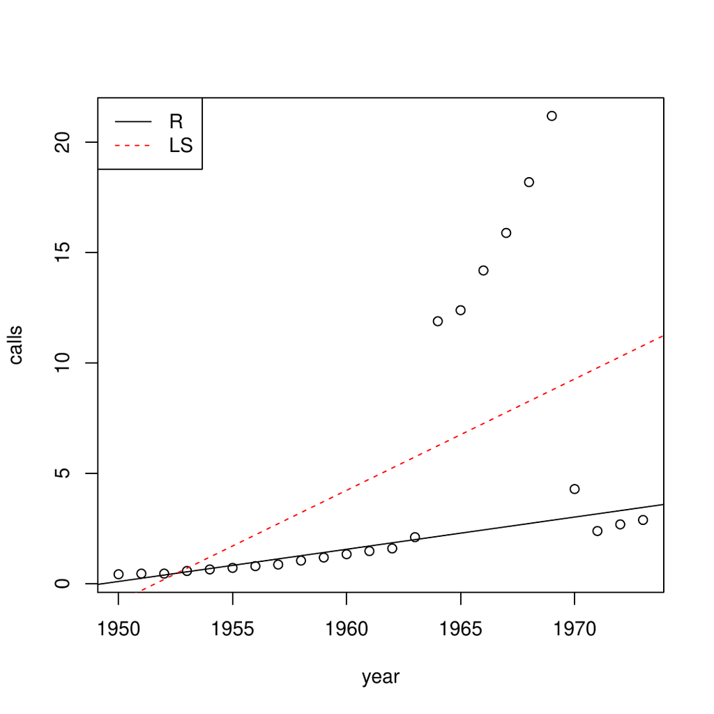

Figure 1: Scatter plot of the telephone data with overlaid regression lines.

```r
> plot(telephone)
> abline(fit)
> abline(lm(calls ~ year, data = telephone),
+     col = 2, lty = 2)
> legend("topleft", legend = c("R", "LS"),
+     col = 1:2, lty = 1:2)
```

Further, the output is similar to that of `lm` and can be interpreted in the same way. The estimate of slope is 0.146 (tens of millions of calls per year) with a standard error of 0.078. The $t$-statistic is the ratio of the two and the $p$-value is calculated using a $t$-distribution with $n-2$ degrees of freedom. Hence one could conclude that year is a marginally significant predictor of the number of telephone calls.

The overlaid fitted regression lines in the scatter plot in Figure 1 demonstrate the robustness of the Wilcoxon fit and the lack of robustness of the least squares fit.

#### Example 2: Free fatty acid data

This is a data set from *Applied Linear Statistical Models* (1987, 64) (c.f. Example 3.9.4 of Hettmansperger and McKean (2011)). The response variable is level of free fatty acid in a sample of prepubescent boys. The explanatory variables are age (in months), weight (in lbs), and skin fold thickness. For this discussion, we chose the Wilcoxon (default) scores for *Rfit*. Based on the residual and Q-Q plots below, however, the underlying error distribution appears to be right-skewed. In a later section we analyze this data set using more appropriate (bent) scores for a right-skewed distribution.

To begin with we demonstrate the reduction in dispersion test discussed in the previous section.

```r
> fitF <- rfit(ffa ~ age + weight + skin,
+     data = ffa)
> fitR <- rfit(ffa ~ skin, data = ffa)
> drop.test(fitF, fitR)
```

```r
Drop in Dispersion Test
F-Statistic     p-value
 1.0754e+01  2.0811e-04
```

As the code segment shows, the syntax is similar to that of the `anova` function used for reduced model testing in many of the parametric packages.

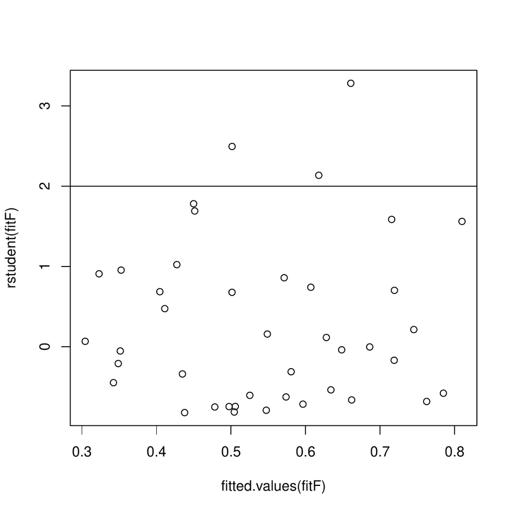

Figure 2: Studentized residuals versus fitted values for the free fatty acid data.

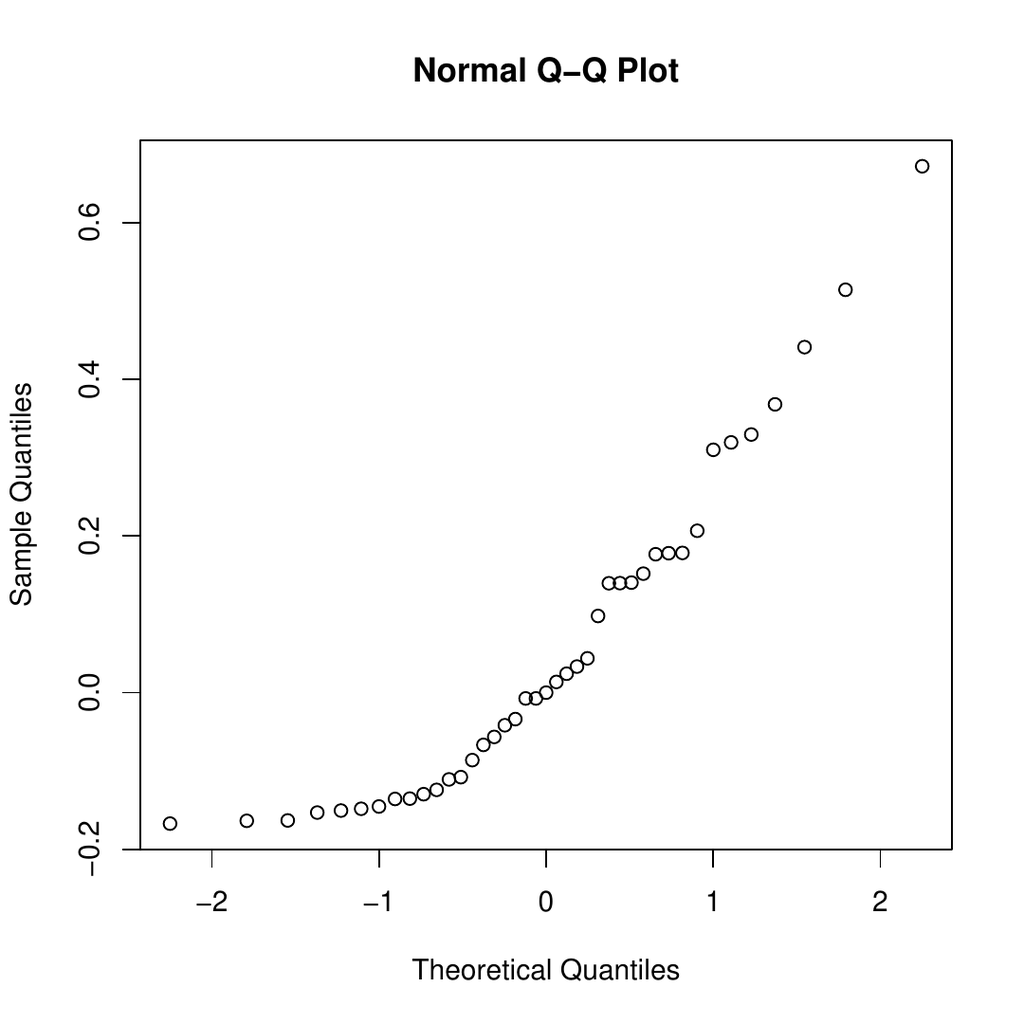

Studentized residuals for rank-based fits are calculated in a way similar to the LS studentized residuals (see Chapter 3 of Hettmansperger and McKean 2011). We have implemented these residuals in *Rfit* and demonstrate their use next. These are the residuals plotted in the residual and Q-Q plots in Figure 2 and Figure 3 respectively. The code is similar to that of least squares analysis. The function `fitted.values` returns the fitted values and `residuals` returns the residuals from the full model fit. The function `rstudent` calculates the studentized residuals.

Common diagnostic tools are the residual plot (Figure 2)

```r
> plot(fitted.values(fitF), rstudent(fitF))
> abline(h = c(-2, 2))
```

```r
> qqnorm(residuals(fitF))
```

As is shown in the plots, there are several outliers and perhaps the errors are from a right skewed distribution. We revist this example in a later section.